# Assignment 5

Kevin Hu

10/10/2019

Load the required libraries

```r
library(gapminder)
library(tidyverse)
library(forcats)
```

## Exercise 1: Explain the value of the here::here package

Using the here::here package will increase the reproducibility of your codes. The user can run your code without changing the absolute path of the root/project directory regardless what operation system the user is using. This is achieved by auto-detecting the root directory, then joining it (in a format that matches the user’s platform) with sub-directories and file name that you specify when the here function is called.

## Exercise 2: Factor management

### Task 1 Drop Oceania in the gapminder dataset

The number of rows in the original data:

```r
nrow(gapminder)
```

```
## [1] 1704
```

The number of levels of *continent* in the original data:

```r
levels(gapminder$continent)
```

```
## [1] "Africa"   "Americas" "Asia"     "Europe"   "Oceania"
```

```r
nlevels(gapminder$continent)
```

```
## [1] 5
```

Drop **Oceania**: Filter the Gapminder data to remove observations associated with the continent of Oceania

```r
DT::datatable(gap <- gapminder %>%
  filter(continent != "Oceania") %>%
  droplevels())
```

|  | country | continent | year | lifeExp | pop | gdpPercap |
| --- | --- | --- | --- | --- | --- | --- |
| 1 | Afghanistan | Asia | 1952 | 28.801 | 8425333 | 779.4453145 |
| 2 | Afghanistan | Asia | 1957 | 30.332 | 9240934 | 820.8530296 |
| 3 | Afghanistan | Asia | 1962 | 31.997 | 10267083 | 853.10071 |
| 4 | Afghanistan | Asia | 1967 | 34.02 | 11537966 | 836.1971382 |
| 5 | Afghanistan | Asia | 1972 | 36.088 | 13079460 | 739.9811058 |
| 6 | Afghanistan | Asia | 1977 | 38.438 | 14880372 | 786.11336 |
| 7 | Afghanistan | Asia | 1982 | 39.854 | 12881816 | 978.0114388 |
| 8 | Afghanistan | Asia | 1987 | 40.822 | 13867957 | 852.3959448 |
| 9 | Afghanistan | Asia | 1992 | 41.674 | 16317921 | 649.3413952 |
| 10 | Afghanistan | Asia | 1997 | 41.763 | 22227415 | 635.341351 |

[output cut: 1670 more lines]

The number of rows after dropping:

```r
nrow(gap)
```

```
## [1] 1680
```

The number of levels of *continent* after dropping:

```r
levels(gap$continent)
```

```
## [1] "Africa"   "Americas" "Asia"     "Europe"
```

```r
nlevels(gap$continent)
```

```
## [1] 4
```

### Task 2 Reorder the levels of continent

Orignal order:

```r
levels(gap$continent)
```

```
## [1] "Africa"   "Americas" "Asia"     "Europe"
```

Figure showing the orignal order:

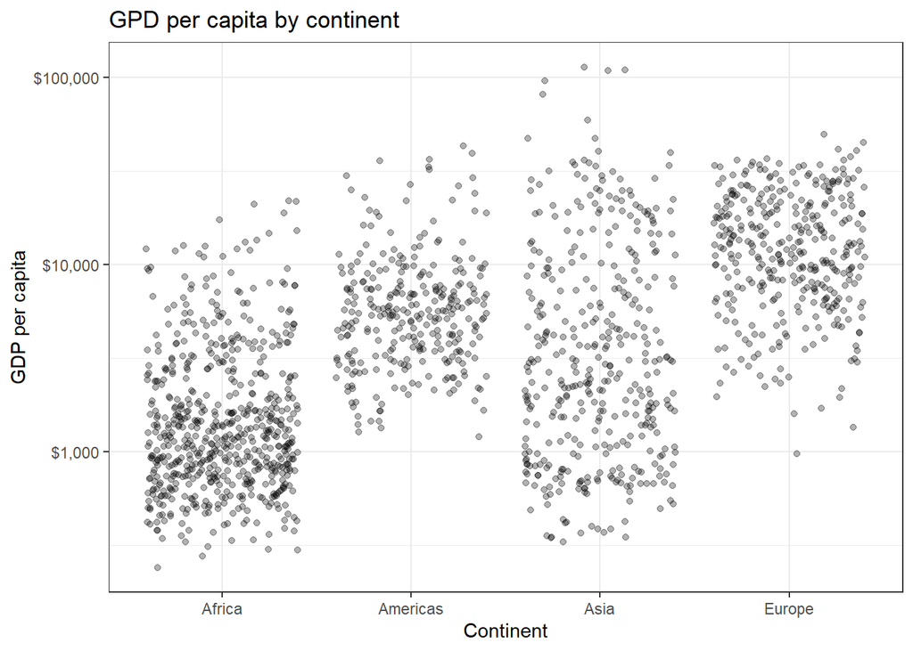

```r
ggplot(gap, aes(continent, gdpPercap)) +
  geom_jitter(alpha = 0.3) +
  labs(x = "Continent", title = "GPD per capita by continent") +
  scale_y_log10("GDP per capita", labels = scales::dollar_format()) +
  theme_bw()
```

Reorder based on the standard deviation of GDP per capita:

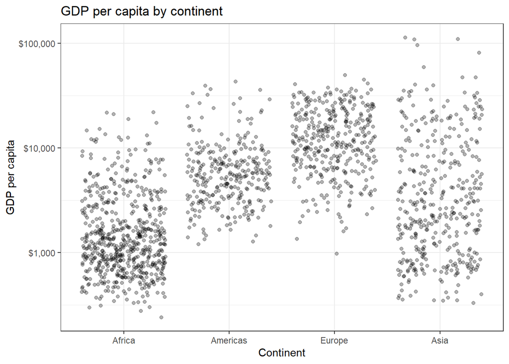

```r
gap %>%
  ggplot() +
  geom_jitter(aes(fct_reorder(continent, gdpPercap, sd), gdpPercap), alpha = 0.3) +
  labs(x = "Continent", title = "GDP per capita by continent") +
  scale_y_log10("GDP per capita", labels = scales::dollar_format()) +
  theme_bw()
```

## Exercise 3: File input/output (I/O)

### Summarize GDP per capita by continent

```r
gap_stat <- gapminder %>%
  group_by(continent) %>%
  summarise(mean_gdp = mean(gdpPercap),
            sd_gdp = sd(gdpPercap))
knitr::kable(gap_stat)
```

| continent | mean_gdp | sd_gdp |
| --- | --- | --- |
| Africa | 2193.755 | 2827.930 |
| Americas | 7136.110 | 6396.764 |
| Asia | 7902.150 | 14045.373 |
| Europe | 14469.476 | 9355.213 |
| Oceania | 18621.609 | 6358.983 |

### Write the summary table as a csv file

I used the following codes to write the csv. R did not allow me to knit if I left this chunk as running code chunk, so I deleted the “{r}” setting it as text.

```
write_csv(gap_stat, here::here("gap_gdp_by_continent.csv"))
```

### Read the file and reorder the levels of continent based on the standard deviation of GDP per capita

Again, R would not knit the file if I loaded the csv using here::here() from my local drive. To solve this, I put the csv file onto GitHub and load it from URL.

```r
gap_import <- read_csv("https://raw.githubusercontent.com/STAT545-UBC-hw-2019-20/stat545-hw-KevinHzq/master/Assignment5/gap_gdp_by_continent.csv")
```

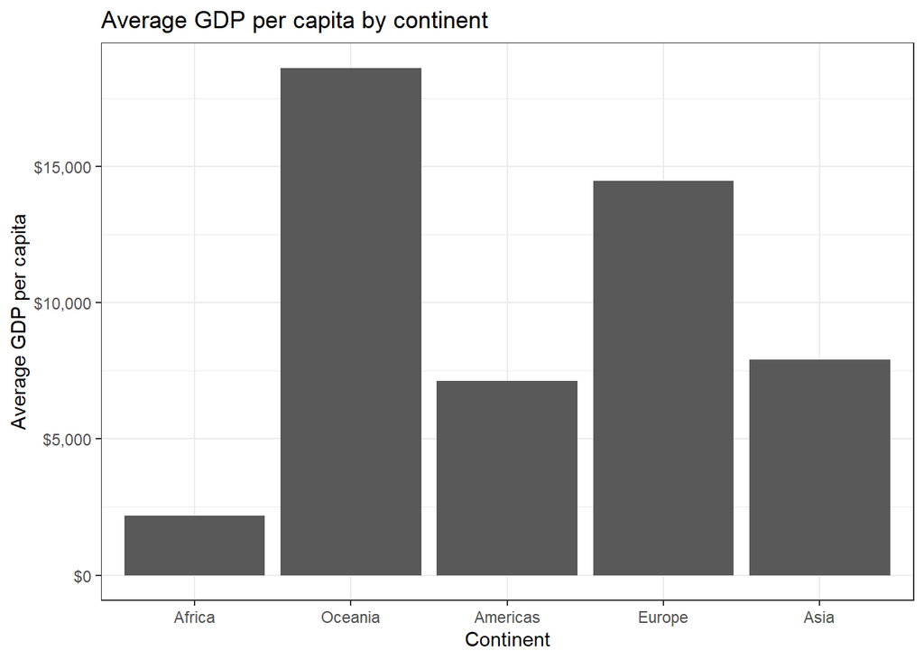

```r
gap_import %>%
  ggplot() +
  geom_col(aes(fct_reorder(continent, sd_gdp), mean_gdp)) +
  labs(x = "Continent", title = "Average GDP per capita by continent") +
  scale_y_continuous("Average GDP per capita", labels = scales::dollar_format()) +
  theme_bw()
```

If you see the graph above, the newly created file survived the round trip of writing to file then reading back in **with my modifications instead of using here package alone**.

## Exercise 4: Visualization design

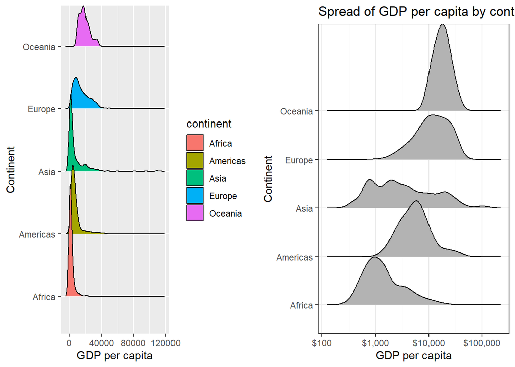

```r
plot_1 <- gapminder %>%
  ggplot(aes(gdpPercap, continent, fill = continent)) +
  labs(x = "GDP per capita", y = "Continent") +
  ggridges::geom_density_ridges()

plot_2 <- gapminder %>%
  ggplot(aes(gdpPercap, continent)) +
  labs(y = "Continent", title = "Spread of GDP per capita by continent") +
  ggridges::geom_density_ridges() +
  scale_x_log10("GDP per capita", labels = scales::dollar_format()) +
  theme_bw()

gridExtra::grid.arrange(plot_1, plot_2, ncol=2)
```

I created the figure on the left for Assignment 3. A few improvements have been made to it, and the result is diplayed on the right.Here are the changes: 1. Title is added 2. The x scale is set to log10 to address the skewness issue in the previous graph 3. Dollar format is used on the x axis to increase readablity 4. The unecessary fill colour and legend are removed 5. The distracting grey background is removed

## Exercise 5: Writing figures to file

I used the following codes to save my new plot above(the one on the right)

```
ggsave("gdp_spread.png", plot = plot_2, path = here::here(), dpi = 300)
```

Let’s load the saved image:

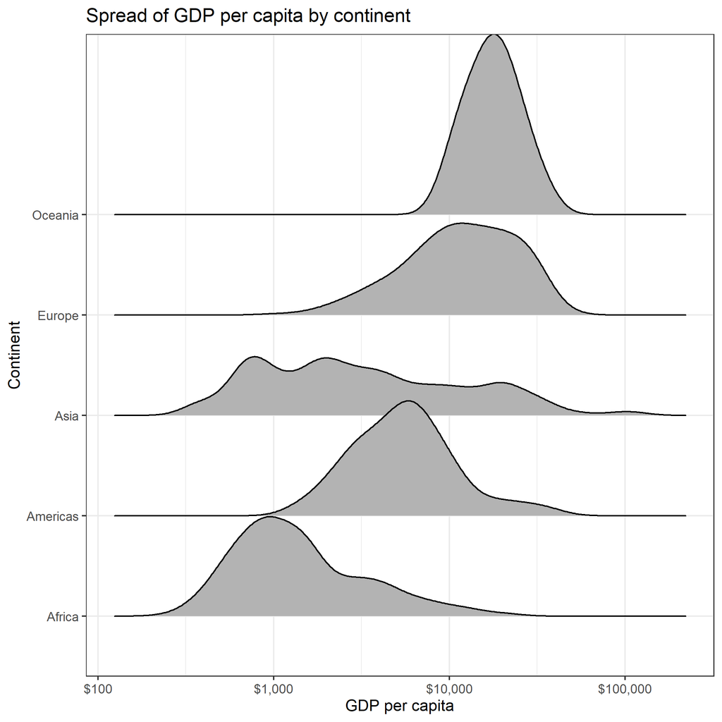